# Data Formats and File Formats

Leighton Pritchard, Morgan Feeney

2021 Presentation

- Data formats and file formats determine how data can be used
- Data formats can be *closed* and *proprietary* or *open*
- Community and other international standards exist for some kinds of data
- There are several factors that should guide your choice of data format
- Avoid using proprietary data formats for exchange or storage of data
- When requesting data, ask for it to be provided in an open format

# 1 Introduction

Depending on the type of project and the analysis you are doing, you may end up generating and dealing with a number of different data formats.

Understanding what type of data you generate, and how it is formatted, is a key part of experimental design. *Before* you perform an experiment, you should already have a good idea of what kind of data it will generate, how you will record it, and how it will be formatted and stored. This is part of a good data management strategy, and making these decisions before performing the experiment can help to avoid introducing unconscious biases that might affect the results.

Different types of experiment generate different types of data, which can be formatted in a variety of ways.

**Click to expand an example of how data can be generated and stored in different formats**

For example, you might analyse the size of DNA fragments using gel electrophoresis, and take an image of the resulting gel using a gel doc. This produces an image, which can be saved as an image file, printed out and pasted in your lab notebook, and interpreted.

The raw data generated by this experiment is the image file. You might also generate a list of DNA fragment sizes, from comparing the sizes of your DNA fragments to standards of known size (the DNA ladder). This is also data and it can be stored in a number of different formats (perhaps a handwritten list in your lab notebook, or as a list in a .txt, .csv, or .docx file. - you might choose any of these formats, based on what is most compatible with the downstream analyses that will be performed on these data, what is most compatible with FAIR principles, and most convenient for you and your colleagues working on the project.)

Regardless of any downstream analyses or data formatting/reformatting decisions, you must *always* save that original copy of the raw data - this is a fundamental principle of good scientific practice.

You must always be able to return to the original data *in the form it was originally collected/recorded*.

Data are often associated with *metadata* - data that provide information about the data.

These data may be in a different format to the data itself (e.g., a text file describing the sample characteristics and other metadata, paired with the sequencing reads obtained from that sample; or, the date and GPS coordinates at which a photograph were taken.)

Without the metadata, the data themselves would lack context and may even be uninterpretable/unusable. It is therefore important that your plan for data management includes a plan for how you will accurately record, format, and store the metadata for your experiments.)

In this workshop we will cover some of the data formats you are most likely to encounter when doing your honours project. You may also encounter some specialised data formats that are outwith the scope of this workshop, but the general rules for good data management still apply.

# 2 Proprietary and Open Formats

## 2.1 Proprietary data formats

*Proprietary* data formats have a format defined and/or controlled by an individual or organisation, often to support their own software and possibly only readable or writable by that software. Examples of proprietary software include: Adobe’s `.psd` files; Nikon’s `.nef` files; and the `.mp3` audio format. The key feature of a proprietary format is that it is, or was, not intended to be publicly known, or to be used without a licence.

Proprietary formats may be *closed proprietary*, in the sense that their specification and definition is a “trade secret” (like Adobe’s `.psd` files), or *open proprietary*, where the specification is published but maintained by a private organisation, like the `.mp3` file format.

## 2.2 Open data formats

*Open* data formats are defined by published, and public, specifications, often under control of a public community, or standards organisation. Open formats include `HTML`, `.png` image files, plain text formats, and the `.odf` OpenDocument format (an alternative to Microsoft’s `.docx` files).

Open formats are independent of any particular software tool or operating system, and are machine-readable, but may or may not be human-readable.

**(Click to toggle) A comparison of proprietary vs open data**

We saved a simple project `README` file - intended to introduce the repository containing these course materials - in four formats, to demonstrate some of the practical differences between proprietary and open formats. In each case, we’re looking at the first few lines of the output file, to compare readability and data content.

**Markdown (open)**

The first file is written in Markdown, an open format with multiple different standards. It is plain-text, human readable, and can describe both metadata and data content.

```bash
$ head README.md
---
output:
  word_document: default
  html_document: default
  pdf_document: default
---
# BM432

Welcome to the BM432 computational biology repository!
```

**HTML (open)**

HTML (HyperText Markup Language) is in some ways the “base language” of the web. It is plain text, human-readable, and can describe both metadata and data content.

```bash
$ head README.html
<!DOCTYPE html>

<html>

<head>

<meta charset="utf-8" />
<meta name="generator" content="pandoc" />
<meta http-equiv="X-UA-Compatible" content="IE=EDGE" />
```

**PDF (proprietary/open)**

The PDF format has multiple versions, some of which are open, and some are proprietary. It can be considered as a hybrid open/proprietary format, and its main disadvantages are that it was designed to be read by specific software, and is often stored in a compressed form, making it more vulnerable to errors in file-copying that can render the file unusable.

```bash
$ head README.pdf
%PDF-1.5
%????
15 0 obj
<<
/Length 1915
/Filter /FlateDecode
>>
stream
xڽX]w?6}???I?(~???i7M?ԻY?m?>P$,aMZ?????0E2??8??3??{/@?m@??/??????XL?8???}?? c??(
                                                                                ??????u???w???IP?"?R??9#9ǡ???h%?J??:??h?+?ܹ?
 ??+u????-???Q?#6?8?C??T'{??3&??B??"?pѻ???~???j??ח?u??e/?,???6v??}?{?y\??C?S7Ft??&R??ƨ1?߽??$@??$J????]|3
                                                                                                       *|?E
                                                                                                           ???ﴲ?GT???-?b/ЧK?m?
?߰??B??_??t?(&i?t??v??eX?9v?{~??o???Ґ??
                                      ?0lYኧ???Ԡ+?ҫK?T???P??3P?????o[~?]?Y??D??k?????AvC??ή??O?We#??????@???????_hl?]???
```

**Word `.docx` (proprietary/open)**

The Microsoft Word `.docx` format is also a mixture of proprietary and open formats. The specification has been made public, but the format again prioritises commercial software and is largely under the control of Microsoft. It is also stored in a compressed form, vulnerable to copy errors.

```bash
$ head README.docx
u*Se݋
???I?8???2??}.^?6??L{!?^R?Ft???-Bb???k?t?+??+?w??=?? ???`??3?,0z???F??,zj?*??   ?
%R??U~ȍ??؋?%??{?Z?p{?x?(?? ?
                            ?oB?Z??-,??b    I??#?6ϕ???R$??B >]$?????R/?S??}???.?`a???@??h??}?4??9),Ĳ??_???tA???.pR??T??A?t?ފK????a?*???e@?/?rCs?z3?/`?I?y??[??;h+Z(?oDZ]uŁ???h,?=Z????{?ou*S?=?^??
                                                                            _rels/.rels???N1
                                                                                            E?|E?}?S
?f?A??C?|@?xj??B?{B@Q??2?????b??81h?V5(
?O4L?rx妠֯?NaǶ,?G???Ȉ_?B6ܑhx???}?????u?ΩC{???M?~???S?y(?&?Q???Jo=?qF
                                                                  ??4.??5?>??.K??}d????8?7u*Sa?)?J&word/document.xml?Z[W?8~?_??3&΅[???圲?Sh?????Zd?G????wF?)?&?dӗ8??????7??ۯ?$3n??jt???p?t"?t|??
                                                                      ???????͊?+G`????(H?ˇ??e)Ϩ??9W?l?MF?4??\?$7?qkA^&;?(:?dT????#FO&??w???6B?K?.????T䶑?GAa԰f?m?ąLg?JJ}if̞?1?d3nލ֐??53?:"+K
```

# 3 Tabular Data

Much of the data we work with can be represented in tabular format (see the What is a Dataset? notebook). This kind of data can be handled intuitively in a spreadsheet application, like Microsoft Excel, Apple’s Numbers, or Google Sheets. However, spreadsheets enable some bad data practices that are best avoided (see below).

In general, so long as care is taken it is reasonable to collect, explore and examine data using spreadsheets, but the data itself is best stored as platform-independent plain text formats, such as `CSV` (Comma-Separated Variable) or `TSV` (Tab-Separated Variable) files, rather than proprietary file formats.

## 3.1 Spreadsheet Bad Practices

Spreadsheets are powerful and useful tools and, when handled with care, can add value to your work quickly.

However, they can **enable and encourage bad practice** and, sometimes, **can make your results invalid without you noticing**.

### 3.1.1 No separation of raw, cleaned and analysed data

It is possible, and common, for people to read their raw data into a spreadsheet, modify the data in-place (data cleaning), and analyse the data in exactly the same worksheet. This goes against good data management principles (see the Data Analysis notebook):

- **keep raw data separate from “cooked” (cleaned/analysed) data**: being able to readily distinguish raw from processed data makes your project workflow more transparent; combining the two in the same worksheet makes analyses harder to follow
- **keep data logically separate from the analysis “code”**: if your analysis takes a data field as input, and produces an output file, it is clear what each part of the workflow is doing, and there is the potential for reusability of the analysis with a new or modified dataset. Spreadsheets combine the dataset with the analysis, making it harder to substitute in a new dataset and rerun the analysis, and sometimes even hard to understand the flow of the analysis itself.
- Some spreadsheet software will allow the use of multiple *worksheets* within a *workbook*, but require saving those files in a proprietary, format that is tied to the specific spreadsheet package, limiting exchange.

### 3.1.2 Point-and-click interface

It is convenient to be able to click on a cell and change its format, or the value. It’s convenient to be able to move data around by clicking, and dragging the mouse pointer. But these are data bad practices.

- **raw data should not be modified**: the spreadsheet interface makes it easy to modify raw data deliberately without any record, and possible to modify it accidentally - again without any record. Most disturbingly, some spreadsheet software, like Excel, can change your data silently, making your analyses invalid. [Excel is known to change gene names without warning](http://ziemann-lab.net/public/gene_name_errors/Report_2021-08.html).
- **annotation and metadata should be explicit and transparent**: for instance, it’s tempting to use spreadsheet colours, or fonts, to “annotate” your data - to indicate high, low, or “faulty” values, for instance, or to categorise groups. Unless there is a clear record of the meanings of those colours, the annotations may not be understandable to others. Some colour choices may be indistinguishable because of colour-blindness. If the file is saved in any way other than the proprietary spreadsheet format, it may be impossible to indicate those colours, potentially locking the data into a short-lived, proprietary format that is hard to share.

### 3.1.3 Closed, proprietary, compressed file formats

By default, spreadsheet software will save your data as a proprietary format for quick reading, writing, and preservation of graphs. These formats are typically tied to the application and vary between versions, making them brittle against version changes, or across operating systems. They are not useful for long-term storage. Although these formats may preserve colour formatting, graphs, and other annotations, those features are not usually able to be extracted easily by other software tools.

# 4 Image Data

Many biological experiments involve collecting image data (e.g., photographs of samples; gel pictures; micrographs captured by light or electron microscopy).

Common image data formats include: .tiff, .gif, .jpg, .png, .bmp, and so on. There are also a large number of proprietary image data formats (e.g. associated with a particular camera or software.)

There are very stringent rules governing the acceptable practices for handling image data.[^1]

Manipulating an image (even seemingly harmless, “artistic” adjustments to scale the brightness or contrast) changes the data and can affect how these data are perceived and interpreted.

Therefore, you must always: - Save a copy of the original, unedited image - Record any adjustments that were made, and how they were made (some software will do this automatically). - Simple manipulations (e.g., cropping to remove irrelevant parts of the image, careful adjustments of brightness and contrast applied to the entire image) are usually acceptable. - Manipulations specific to one part of the image, or that duplicate part of an image, are questionable at best - and usually completely unethical. - Be sure to compare the original and processed image, to ensure that the manipulations do not alter the data.

See the [Image integrity and standards, Nature journals](https://www.nature.com/nature-portfolio/editorial-policies/image-integrity) for an example of the rules that journals set out to ensure that image data is acquired and processed appropriately. If you do not follow such guidelines, your data will be unpublishable.

## 4.1 Image Compression

Image files can be very large - and some experiments (e.g., time-lapse microscopy) involve the acquisition of hundreds of thousands of images. There are algorithms which can compress these files into smaller files - these generally fall into two categories, *lossless* and *lossy*. Lossy compression, as the name implies, results in the loss of some of the original data (often resulting in a smaller image file than lossless compression, which preserves all of the image data.)

For example, micrograph files are commonly captured as .tiff files. It may be tempting to compress these, for example, to .jpg files in order to save space. However, this is an example of lossy compression and therefore the temptation should be avoided! Always retain the original .tiff files from your experiments. (Your data management plan should take into account the storage requirements for acquiring and preserving such large amounts of data.)

# 5 Specialised Data Formats

There are a number of specialised data formats that you may encounter during the course of your project or your further studies. The following is not an exhaustive discussion of all possible file formats used in biological experiments, but is intended as a guide to some of the common fomats that you may encounter.

## 5.1 Nucleotide and amino acid sequence files

FASTA files are text files, with a simple header, while Genbank files generally contain much more detailed information (annotation, references, remarks, etc.)

As an example, consider the .fasta and .gbk files for the *Caulobacter crescentus* gene *dnaA*.

Note that while Genbank files usually describe a single biological molecule (nucleotide or amino acid), FASTA files can contain the sequences of multiple molecules, each labelled with their own FASTA header.

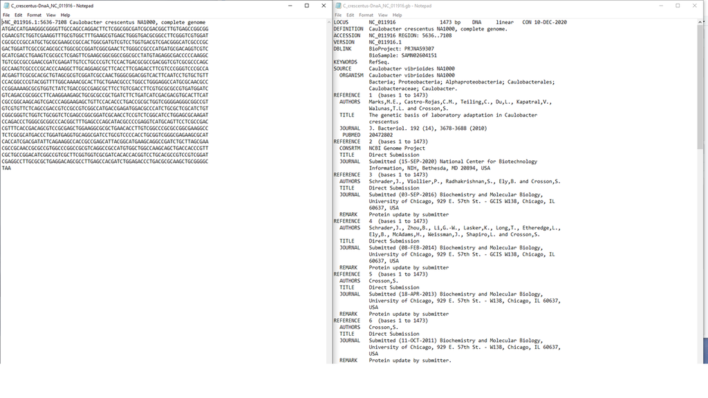

Figure 5.1: A comparison of .fasta and .gbk files for the *Caulobacter crescentus* gene *dnaA*

## 5.2 Structure files

The current standard format for biological macromolecule structure files is the [PDBx/mmCIF](https://www.wwpdb.org/documentation/file-format) format (before 2012, it was the PDB format; older structures may still be in this format.) [Documentation and FAQ](https://mmcif.wwpdb.org/) are available.

## 5.3 Raw sequencing reads

If you are doing experiments that involve DNA sequencing, your data will be generated in different formats depending on the sequencing technology you use. Some commonly used formats include FASTQ and ABI files.

### 5.3.1 FASTQ files

As the name suggests, FASTQ files are similar to FASTA files; however, FASTQ files include quality scores that reflect the quality of the base call.

### 5.3.2 ABI files

If you sequence any samples using Sanger sequencing, the raw sequence data is usually in the ABI file format: this contains the chromatogram showing the peaks generated during the sequencing run.

You will likely also receive a FASTA file containing the bases called during the sequencing run - however, you should always examine the raw data (the chromatogram) carefully.

In the figure below, you can see an example of heterozygosity - the sequencing read is relatively clean and most peaks are well-defined and correctly called, but in some cases there are mixed peaks (for example, peak 358 with A/G peaks). Peak-calling software are not well-equipped to deal with mixed peaks, and so it is important that you examine the sequence chromatograms manually.

[figure not shown]

Figure 5.2: An example of a DNA chromatogram showing heterozygosity (Figure from Mallet 2019, 10.11646/zootaxa.4679.3.11)

# 6 How Should I Choose Formats?

There is no hard-and-fast rule for the most appropriate format(s) for your research data, though there are a number of considerations that can guide your choice (see below).

For openness, transparency, and longevity, it is usually best to prioritise:

- non-proprietary formats
- unencrypted data formats
- uncompressed data formats
- formats that are common and widely-used in your field of work
- open, standardised data formats
- plain-text human readable formats (depending on data type)
- formats that strongly associate data with corresponding metadata
- formats that can be stored and accessed conveniently
- formats that are compatible with downstream analyses
- formats that are acceptable to scientific publishers (e.g., for journal deposition requirements)

## 6.1 Choose data and file formats common in your field

Each academic field tends to reach some kind of consensus on which formats are most commonly or widely used. This may be, for example, because the data format expresses the data well, or because one or other software tool (and its associated file format) is very common.

These often may be codified, for example by journal or database policies specifying which file formats are acceptable for submission. If you do not pay attention to these policies, your data will not be correctly formatted for publication.

To maximise your ability to exchange data, you should choose data formats that are appropriate and common in your own field of research.

## 6.2 Choose a data and file format that will preserve your data for an appropriate time

A critical question is: how long do you need your data to be readable and exchangeable? If you do not require ever to share your data, and it exists for a very short time, the format choice is governed entirely by the ability to store efficiently all the data you need. But the longer you need to keep your data, and the greater the need for exchangeability, the more you will want to consider open, standardised and well-documented file formats.

Open, standardised formats are preferred for persistent storage because proprietary and closed formats may change specification without documentation, and so can become obsolete. It happens quite frequently that later versions of tools introduce features that cannot be read in earlier versions, or discontinue support for earlier features (e.g. [Microsoft Office compatibility changes](https://support.microsoft.com/en-gb/office/compatibility-changes-between-versions-692289af-b760-4698-8326-14b2edcd6552)).

[^1]: Cromey D. W. (2013). Digital images are data: and should be treated as such. Methods in molecular biology (Clifton, N.J.), 931, 1–27. https://doi.org/10.1007/978-1-62703-056-4_1